# Reproducible Report

This report re-produces the analysis of Experiment 1 reported in Mehr, Song, & Spelke (2016). The citation for the article is:

Mehr, S. A., Song, L. A., & Spelke, E. S. (2016). For 5-Month-Old Infants, Melodies Are Social. Psychological Science, 27(4), 486–501.

The data was retrieved from https://osf.io/y3kzd/

Introduction:

The research question examined in the current study was that musical melody conveys social information to infants. The study specifically examined whether infants will selectively attend more to a new person who sings a melody that the child has learned previously in a social setting, over a new person singing an unfamiliar melody. This hypothesis is based on the theory that specific melodies may signal affiliation with a specific social group. In the past, before sound recording technology, when humans would make up songs, only those in their social circles would be familiar with the song. It is highly unlikely that individuals they are not affiliated with would make up the exact same songs. Therefore, familiarity with a particular melody indicated that one belongs in the same social environment. A novel person who sings a familiar melody is most likely affiliated with one’s social group than a novel person singing an unfamiliar melody.

In the current experiment, parents were randomly assigned to learn one of two novel songs, that were equitable in lyrics and rhythms, and differed only in their melody. The parents were instructed to sing their song to their infants over a period of 1-2 weeks. The parents and infants then returned to the lab where the infants participated in a selective-attention task. The task had four trials. In the initial baseline trial, the infants viewed side-by-side video recordings of two unfamiliar individuals who were smiling at the infants. Then the infants viewed a video of one of the individuals singing one of the two songs (either the familiar or familiar song), followed by a second video of the other individual singing the other song. These were the familiarization trials. The task concluded with a fourth trial that was identical to the initial baseline trial. This was the test trial. All conditions (order of songs, which novel individual sings which song), were counterbalanced. Selective attention by the infants was measured as the amount of time the infant spent looking at either novel individual.

The researchers hypothesized that if songs covey social meaning to infants, then the infants will selectively attend to (i.e. spend more time gazing at) a novel individual singing a familiar song at the final test trial.

Reproduction of Analysis:

```r
#Load data into R
loadeddata<-read.csv(file="LUL_pss.csv",fileEncoding="UTF-8-BOM")

#Load needed packages
library(papaja)
library(dplyr)
```

```r
library(ggplot2)
library(tidyr)

#Filter data so only experiment 1 data is used
alldata<-loadeddata %>% filter(exp1 == 1)
```

In their analysis, the authors first performed a one-sample t-test to examine whether there were any differences in the time infants spent looking at either individual at baseline. Specifically, they examined whether the proportion of time infants spent looking at the person who sang the familiar song later in the task differed from chance (50%).

```r
#Perform one sample t-test to determine if the proportion of time the infants spent looking at the novel person who later sang the familiar song did not differ from chance

t.test(alldata$pref1, mu=.5)
```

```
##
##  One Sample t-test
##
## data:  alldata$pref1
## t = 0.67438, df = 31, p-value = 0.5051
## alternative hypothesis: true mean is not equal to 0.5
## 95 percent confidence interval:
##  0.4572940 0.5848994
## sample estimates:
## mean of x
## 0.5210967
```

The authors concluded that the proportion of time at baseline infants spent looking at the individual who would later sing the familiar song did not differ by chance, which was replicated in the current analysis as well; $M = 0.52$, 95% CI $[0.46$, $0.58]$, $t(31) = 0.67$, $p = .505$

Following the baseline trial, two trials followed, during which each novel individual sang a song to the infant (either the familiar or unfamiliar song), one at a time. The authors wanted to ensure that the infants spent the same amount of time looking at each of the novel individuals when they were singing their songs in each trial. To do so, the authors conducted a paired-sample t-test to compare the amount of time the infants spent attending to each novel individual

```r
#Perform paired-sample t-test to determine that the infants spent the same amount of time looking at each of the new individuals during the familiarization trials

t.test(alldata$famfam,alldata$famun,paired=TRUE)
```

```
##
##  Paired t-test
##
## data:  alldata$famfam and alldata$famun
## t = 0.28191, df = 31, p-value = 0.7799
## alternative hypothesis: true difference in means is not equal to 0
## 95 percent confidence interval:
##  -52.41001  69.22251
## sample estimates:
## mean of the differences
##                 8.40625
```

The authors concluded that there were no significant differences in the time the infants spent looking at the individual singing the familiar song versus the individual singing the unfamiliar song during the familiarization trials, which was replicated in the current analysis; $M_d = 8.41$, 95% CI $[-52.41$, $69.22]$, $t(31) = 0.28$, $p = .780$

Lastly, the authors examined the amount of time the infants spent gazing at the individuals at the final test trial, where the individuals were smiling at the infant after both had sung their songs.  
The authors conducted a one-sample t-test to examine whether the infant spent more time than chance gazing at the singer of the familiar song. They also conducted a paired-sample t-test to examine whether the infant spent more time gazing at the singer of the familiar song during the test trial (after she sang the song) than they did during the baseline trial (before she sang the song).

```r
#Perform one sample t-test to determine if the proportion of time during the test trial (after novel individuals sang the songs) the infants spent looking at the novel person who sang the familiar song differed from chance

t.test(alldata$pref2, mu=.5)
```

```
##
##  One Sample t-test
##
## data:  alldata$pref2
## t = 2.9597, df = 31, p-value = 0.005856
## alternative hypothesis: true mean is not equal to 0.5
## 95 percent confidence interval:
##  0.5290672 0.6579153
## sample estimates:
## mean of x
## 0.5934913
```

```r
#Perform paired-sample t-test to determine if the infants spent more time gazing at the singer of the familiar song after she sang, compared to before she sang the familiar song

t.test(alldata$pref2,alldata$pref1,paired=TRUE)
```

```
##
##  Paired t-test
##
## data:  alldata$pref2 and alldata$pref1
## t = 2.4164, df = 31, p-value = 0.02175
## alternative hypothesis: true difference in means is not equal to 0
## 95 percent confidence interval:
##  0.01129217 0.13349698
## sample estimates:
## mean of the differences
##              0.07239458
```

```r
#Determine mean time spent looking at singer of familiar song at test (data is reported as proportion of time (out of 100%))

Prop_test<-mean(alldata$pref2)

#Determine mean time spent looking at singer of familiar song at baseline (data is recorded as proportion of time (out of 100%))

Prop_bl<-mean(alldata$pref1)
```

As reported in their paper and replicated here, the authors found that there was a significant difference between the amount of time the infants spent gazing at the singer of the familiar song at test (after she sang the song), compared to chance;$M = 0.59$, 95% CI $[0.53$, $0.66]$, $t(31) = 2.96$, $p = .006$. The infants spent 59.3% of the time during the test trial gazing at the singer of the familiar song.

The authors also found that there was a significant difference between the amount of time the infants spent gazing at the singer of the familiar song at test (after she sang the song) compared to baseline (before she sang the song);$M_d = 0.07$, 95% CI $[0.01$, $0.13]$, $t(31) = 2.42$, $p = .022$. As reported above, the infants spent 59.3% of the time during the test trial gazing at the singer of the familiar song, compared to 52.1% of the time during the baseline trial. This finding is graphed below:

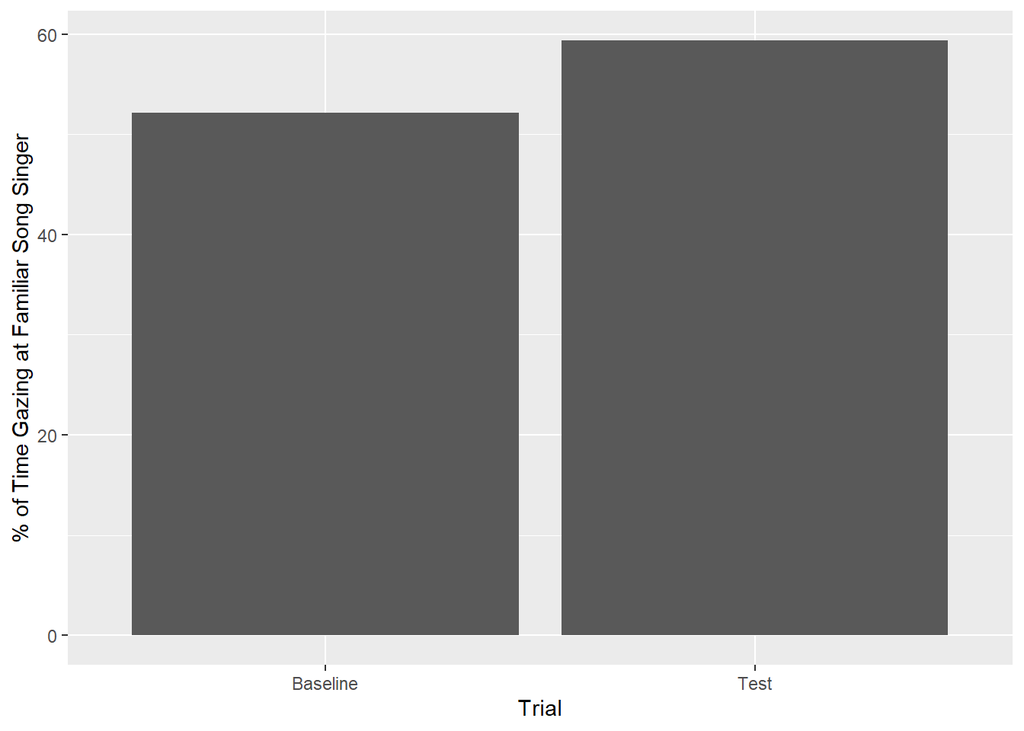

```r
plot_proportion <- data.frame(Trial=c("Baseline", "Test"),
                Proportion=c(Prop_bl*100, Prop_test*100))


ggplot(plot_proportion, aes(x=Trial, y=Proportion)) +
  geom_bar(stat="identity")+
   ylab("% of Time Gazing at Familiar Song Singer")
```

I successfully replicated the statistical analysis of Experiment 1 of Mehr, Song, & Spelke (2016). I was able to reach the same conclusion as the authors; infants spent more time selectively paying attention to a novel person that sang a song that was familiar to the infant (as their parents had sang the same song), which suggests that song melodies may carry socially-relevant information to infants.